# Untitled

Dan Murphy

Friday, October 17, 2014

Suppose you have a triangle in Excel that you would like to analyze in R. In Excel, select the cells comprising the triangle *including the labels identifying accident year and age* and copy to the clipboard.

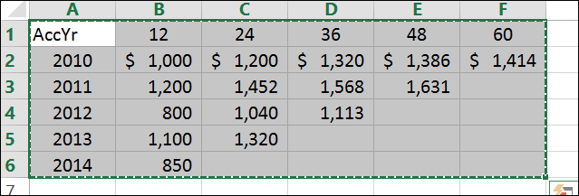

Back in R, load the excelRio package and run the function that pastes content from the clipboard. Be sure to tell the function that your data has a “header” for the column names and a “rowheader” for the row names.

```r
library(excelRio)
tri <- pasteFromExcel(header = TRUE, rowheader = TRUE)
tri
```

```
##        12   24   36   48   60
## 2010 1000 1200 1320 1386 1414
## 2011 1200 1452 1568 1631   NA
## 2012  800 1040 1113   NA   NA
## 2013 1100 1320   NA   NA   NA
## 2014  850   NA   NA   NA   NA
```

Note: The clipboard is a text-oriented storage facility. When copying cell content to the clipboard from Excel, what actually gets copied is the character representation of the cell content as displayed on the screen. Normally, the dollar signs and commas in the numbers would not allow R to convert the character data to numeric, as below the first two character values become NA.

```r
as.numeric(c("$1,000", "1,200", "800"))
```

```
## [1]  NA  NA 800
```

But excelRio looks to see if the contents can be converted to numeric without such “adornments,” and does the conversion if possible.